# Unsupervised Learning: Trade&Ahead

**Marks: 60**

### Context

The stock market has consistently proven to be a good place to invest in and save for the future. There are a lot of compelling reasons to invest in stocks. It can help in fighting inflation, create wealth, and also provides some tax benefits. Good steady returns on investments over a long period of time can also grow a lot more than seems possible. Also, thanks to the power of compound interest, the earlier one starts investing, the larger the corpus one can have for retirement. Overall, investing in stocks can help meet life's financial aspirations.

It is important to maintain a diversified portfolio when investing in stocks in order to maximise earnings under any market condition. Having a diversified portfolio tends to yield higher returns and face lower risk by tempering potential losses when the market is down. It is often easy to get lost in a sea of financial metrics to analyze while determining the worth of a stock, and doing the same for a multitude of stocks to identify the right picks for an individual can be a tedious task. By doing a cluster analysis, one can identify stocks that exhibit similar characteristics and ones which exhibit minimum correlation. This will help investors better analyze stocks across different market segments and help protect against risks that could make the portfolio vulnerable to losses.

### Objective

Trade&Ahead is a financial consultancy firm who provide their customers with personalized investment strategies. They have hired you as a Data Scientist and provided you with data comprising stock price and some financial indicators for a few companies listed under the New York Stock Exchange. They have assigned you the tasks of analyzing the data, grouping the stocks based on the attributes provided, and sharing insights about the characteristics of each group.

### Data Dictionary

- Ticker Symbol: An abbreviation used to uniquely identify publicly traded shares of a particular stock on a particular stock market
- Company: Name of the company
- GICS Sector: The specific economic sector assigned to a company by the Global Industry Classification Standard (GICS) that best defines its business operations
- GICS Sub Industry: The specific sub-industry group assigned to a company by the Global Industry Classification Standard (GICS) that best defines its business operations
- Current Price: Current stock price in dollars
- Price Change: Percentage change in the stock price in 13 weeks
- Volatility: Standard deviation of the stock price over the past 13 weeks
- ROE: A measure of financial performance calculated by dividing net income by shareholders' equity (shareholders' equity is equal to a company's assets minus its debt)
- Cash Ratio: The ratio of a company's total reserves of cash and cash equivalents to its total current liabilities
- Net Cash Flow: The difference between a company's cash inflows and outflows (in dollars)
- Net Income: Revenues minus expenses, interest, and taxes (in dollars)
- Earnings Per Share: Company's net profit divided by the number of common shares it has outstanding (in dollars)
- Estimated Shares Outstanding: Company's stock currently held by all its shareholders
- P/E Ratio: Ratio of the company's current stock price to the earnings per share
- P/B Ratio: Ratio of the company's stock price per share by its book value per share (book value of a company is the net difference between that company's total assets and total liabilities)

## Importing necessary libraries and data

```python
# Libraries to help with reading and manipulating data
import numpy as np
import pandas as pd

# Libraries to help with data visualization
import matplotlib.pyplot as plt
import seaborn as sns

sns.set_theme(style='darkgrid')

# Removes the limit for the number of displayed columns
pd.set_option("display.max_columns", None)
# Sets the limit for the number of displayed rows
pd.set_option("display.max_rows", 200)

# to scale the data using z-score
from sklearn.preprocessing import StandardScaler

# to compute distances
from scipy.spatial.distance import cdist, pdist

# to perform k-means clustering and compute silhouette scores
from sklearn.cluster import KMeans
from sklearn.metrics import silhouette_score

!pip install yellowbrick
# to visualize the elbow curve and silhouette scores
from yellowbrick.cluster import KElbowVisualizer, SilhouetteVisualizer

# to perform hierarchical clustering, compute cophenetic correlation, and create dendrograms
from sklearn.cluster import AgglomerativeClustering
from scipy.cluster.hierarchy import dendrogram, linkage, cophenet

# to suppress warnings
import warnings
warnings.filterwarnings("ignore")
```

## Data Overview

- Observations
- Sanity checks

```python
data = pd.read_csv("/Users/camilaconyers/Downloads/stock_data.csv")
```

## Exploratory Data Analysis (EDA)

- EDA is an important part of any project involving data.
- It is important to investigate and understand the data better before building a model with it.
- A few questions have been mentioned below which will help you approach the analysis in the right manner and generate insights from the data.
- A thorough analysis of the data, in addition to the questions mentioned below, should be done.

**Questions**:

1. What does the distribution of stock prices look like?
2. The stocks of which economic sector have seen the maximum price increase on average?
3. How are the different variables correlated with each other?
4. Cash ratio provides a measure of a company's ability to cover its short-term obligations using only cash and cash equivalents. How does the average cash ratio vary across economic sectors?
5. P/E ratios can help determine the relative value of a company's shares as they signify the amount of money an investor is willing to invest in a single share of a company per dollar of its earnings. How does the P/E ratio vary, on average, across economic sectors?

### Checking the shape of the dataset

```python
print(f"There are {data.shape[0]} rows and {data.shape[1]} columns.")
```

```
There are 340 rows and 15 columns.
```

### Displaying few rows of the dataset

```python
# let's view a sample of the data
data.sample(n=10, random_state=1)
```

|  | Ticker Symbol | Security | GICS Sector | GICS Sub Industry | Current Price | Price Change | Volatility | ROE | Cash Ratio | Net Cash Flow | Net Income | Earnings Per Share | Estimated Shares Outstanding | P/E Ratio | P/B Ratio |
| --- | --- | --- | --- | --- | --- | --- | --- | --- | --- | --- | --- | --- | --- | --- | --- |
| 102 | DVN | Devon Energy Corp. | Energy | Oil & Gas Exploration & Production | 32.000000 | -15.478079 | 2.923698 | 205 | 70 | 830000000 | -14454000000 | -35.55 | 4.065823e+08 | 93.089287 | 1.785616 |
| 125 | FB | Facebook | Information Technology | Internet Software & Services | 104.660004 | 16.224320 | 1.320606 | 8 | 958 | 592000000 | 3669000000 | 1.31 | 2.800763e+09 | 79.893133 | 5.884467 |
| 11 | AIV | Apartment Investment & Mgmt | Real Estate | REITs | 40.029999 | 7.578608 | 1.163334 | 15 | 47 | 21818000 | 248710000 | 1.52 | 1.636250e+08 | 26.335526 | -1.269332 |
| 248 | PG | Procter & Gamble | Consumer Staples | Personal Products | 79.410004 | 10.660538 | 0.806056 | 17 | 129 | 160383000 | 636056000 | 3.28 | 4.913916e+08 | 24.070121 | -2.256747 |
| 238 | OXY | Occidental Petroleum | Energy | Oil & Gas Exploration & Production | 67.610001 | 0.865287 | 1.589520 | 32 | 64 | -588000000 | -7829000000 | -10.23 | 7.652981e+08 | 93.089287 | 3.345102 |
| 336 | YUM | Yum! Brands Inc | Consumer Discretionary | Restaurants | 52.516175 | -8.698917 | 1.478877 | 142 | 27 | 159000000 | 1293000000 | 2.97 | 4.353535e+08 | 17.682214 | -3.838260 |
| 112 | EQT | EQT Corporation | Energy | Oil & Gas Exploration & Production | 52.130001 | -21.253771 | 2.364883 | 2 | 201 | 523803000 | 85171000 | 0.56 | 1.520911e+08 | 93.089287 | 9.567952 |
| 147 | HAL | Halliburton Co. | Energy | Oil & Gas Equipment & Services | 34.040001 | -5.101751 | 1.966062 | 4 | 189 | 7786000000 | -671000000 | -0.79 | 8.493671e+08 | 93.089287 | 17.345857 |
| 89 | DFS | Discover Financial Services | Financials | Consumer Finance | 53.619999 | 3.653584 | 1.159897 | 20 | 99 | 2288000000 | 2297000000 | 5.14 | 4.468872e+08 | 10.431906 | -0.375934 |
| 173 | IVZ | Invesco Ltd. | Financials | Asset Management & Custody Banks | 33.480000 | 7.067477 | 1.580839 | 12 | 67 | 412000000 | 968100000 | 2.26 | 4.283628e+08 | 14.814159 | 4.218620 |

### Checking the data types of the columns for the dataset

```python
# checking the column names and datatypes
data.info()
```

```
<class 'pandas.core.frame.DataFrame'>
RangeIndex: 340 entries, 0 to 339
Data columns (total 15 columns):
 #   Column                        Non-Null Count  Dtype
---  ------                        --------------  -----
 0   Ticker Symbol                 340 non-null    object
 1   Security                      340 non-null    object
 2   GICS Sector                   340 non-null    object
 3   GICS Sub Industry             340 non-null    object
 4   Current Price                 340 non-null    float64
 5   Price Change                  340 non-null    float64
 6   Volatility                    340 non-null    float64
 7   ROE                           340 non-null    int64
 8   Cash Ratio                    340 non-null    int64
 9   Net Cash Flow                 340 non-null    int64
 10  Net Income                    340 non-null    int64
 11  Earnings Per Share            340 non-null    float64
 12  Estimated Shares Outstanding  340 non-null    float64
 13  P/E Ratio                     340 non-null    float64
 14  P/B Ratio                     340 non-null    float64
dtypes: float64(7), int64(4), object(4)
memory usage: 40.0+ KB
```

### Creating a copy of original data

```python
# copying the data to another variable to avoid any changes to original data
df = data.copy()
```

### Checking for duplicates and missing values

```python
# checking for duplicate values
print(f"Number of duplicate rows: {df.duplicated().sum()}")

# checking for missing values in the data
print(f"Number of missing values in each column:\n{df.isnull().sum()}")
```

```
Number of duplicate rows: 0
Number of missing values in each column:
Ticker Symbol                   0
Security                        0
GICS Sector                     0
GICS Sub Industry               0
Current Price                   0
Price Change                    0
Volatility                      0
ROE                             0
Cash Ratio                      0
Net Cash Flow                   0
Net Income                      0
Earnings Per Share              0
Estimated Shares Outstanding    0
P/E Ratio                       0
P/B Ratio                       0
dtype: int64
```

### Statistical summary of the dataset

**Let's check the statistical summary of the data.**

```python
df.describe(include='all').T
```

|  | count | unique | top | freq | mean | std | min | 25% | 50% | 75% | max |
| --- | --- | --- | --- | --- | --- | --- | --- | --- | --- | --- | --- |
| Ticker Symbol | 340 | 340 | AAL | 1 | NaN | NaN | NaN | NaN | NaN | NaN | NaN |
| Security | 340 | 340 | American Airlines Group | 1 | NaN | NaN | NaN | NaN | NaN | NaN | NaN |
| GICS Sector | 340 | 11 | Industrials | 53 | NaN | NaN | NaN | NaN | NaN | NaN | NaN |
| GICS Sub Industry | 340 | 104 | Oil & Gas Exploration & Production | 16 | NaN | NaN | NaN | NaN | NaN | NaN | NaN |
| Current Price | 340.0 | NaN | NaN | NaN | 80.862345 | 98.055086 | 4.5 | 38.555 | 59.705 | 92.880001 | 1274.949951 |
| Price Change | 340.0 | NaN | NaN | NaN | 4.078194 | 12.006338 | -47.129693 | -0.939484 | 4.819505 | 10.695493 | 55.051683 |
| Volatility | 340.0 | NaN | NaN | NaN | 1.525976 | 0.591798 | 0.733163 | 1.134878 | 1.385593 | 1.695549 | 4.580042 |
| ROE | 340.0 | NaN | NaN | NaN | 39.597059 | 96.547538 | 1.0 | 9.75 | 15.0 | 27.0 | 917.0 |
| Cash Ratio | 340.0 | NaN | NaN | NaN | 70.023529 | 90.421331 | 0.0 | 18.0 | 47.0 | 99.0 | 958.0 |
| Net Cash Flow | 340.0 | NaN | NaN | NaN | 55537620.588235 | 1946365312.175789 | -11208000000.0 | -193906500.0 | 2098000.0 | 169810750.0 | 20764000000.0 |
| Net Income | 340.0 | NaN | NaN | NaN | 1494384602.941176 | 3940150279.327937 | -23528000000.0 | 352301250.0 | 707336000.0 | 1899000000.0 | 24442000000.0 |
| Earnings Per Share | 340.0 | NaN | NaN | NaN | 2.776662 | 6.587779 | -61.2 | 1.5575 | 2.895 | 4.62 | 50.09 |
| Estimated Shares Outstanding | 340.0 | NaN | NaN | NaN | 577028337.754029 | 845849595.417695 | 27672156.86 | 158848216.1 | 309675137.8 | 573117457.325 | 6159292035.0 |
| P/E Ratio | 340.0 | NaN | NaN | NaN | 32.612563 | 44.348731 | 2.935451 | 15.044653 | 20.819876 | 31.764755 | 528.039074 |
| P/B Ratio | 340.0 | NaN | NaN | NaN | -1.718249 | 13.966912 | -76.119077 | -4.352056 | -1.06717 | 3.917066 | 129.064585 |

## Exploratory Data Analysis

### Univariate analysis

```python
# function to plot a boxplot and a histogram along the same scale.


def histogram_boxplot(df, feature, figsize=(12, 7), kde=False, bins=None):
    """
    Boxplot and histogram combined

    data: dataframe
    feature: dataframe column
    figsize: size of figure (default (12,7))
    kde: whether to the show density curve (default False)
    bins: number of bins for histogram (default None)
    """
    f2, (ax_box2, ax_hist2) = plt.subplots(
        nrows=2,  # Number of rows of the subplot grid= 2
        sharex=True,  # x-axis will be shared among all subplots
        gridspec_kw={"height_ratios": (0.25, 0.75)},
        figsize=figsize,
    )  # creating the 2 subplots
    sns.boxplot(
        data=df, x=feature, ax=ax_box2, showmeans=True, color="violet"
    )  # boxplot will be created and a star will indicate the mean value of the column
    sns.histplot(
        data=df, x=feature, kde=kde, ax=ax_hist2, bins=bins, palette="winter"
    ) if bins else sns.histplot(
        data=df, x=feature, kde=kde, ax=ax_hist2
    )  # For histogram
    ax_hist2.axvline(
        df[feature].mean(), color="green", linestyle="--"
    )  # Add mean to the histogram
    ax_hist2.axvline(
        df[feature].median(), color="black", linestyle="-"
    )  # Add median to the histogram
```

**`Current Price`**

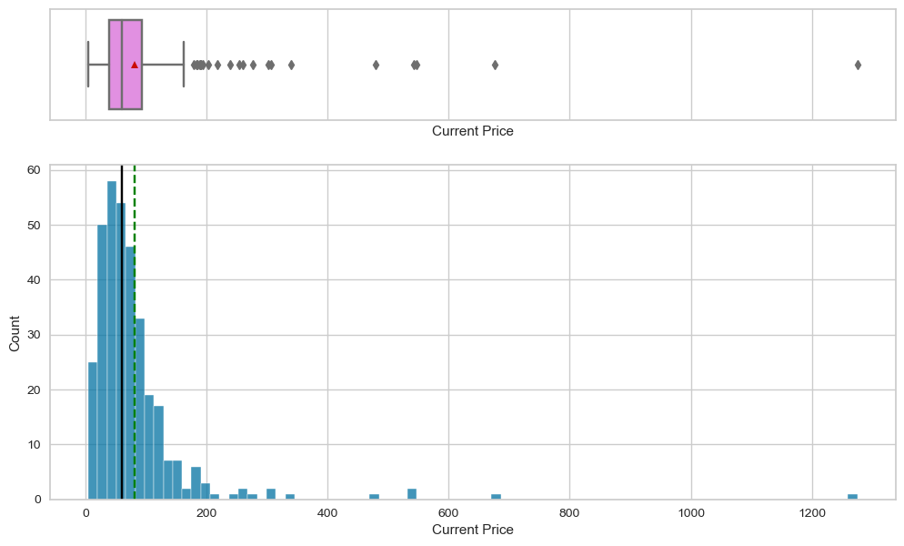

```python
histogram_boxplot(df, 'Current Price')
```

### Insights & Comments:

- The majority of the companies have stock prices below $200.
- The distribution of stock prices is right-skewed, which means there are few companies with very high stock prices that are pulling the average up. This is confirmed by the outliers seen in the boxplot.
- The average (indicated by the red triangle in the boxplot and green dotted line in the histogram) seems to be around $80, which matches the mean value we discussed from the statistical summary.
- The presence of outliers on the higher side indicates that there are a few companies with significantly higher stock prices compared to others. These might be well-established or large-cap companies.

**`Price Change`**

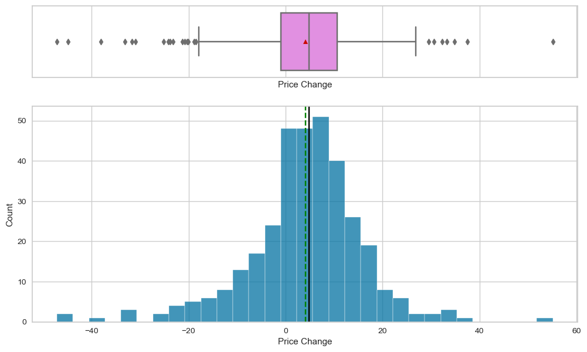

```python
histogram_boxplot(df, 'Price Change')
```

### Insights & Comments:

- The majority of price changes are centered around 0, with many stocks seeing little to no change.
- There are more stocks that have seen a positive price change than those with a negative change, as evidenced by the more substantial frequency on the right side of the 0 mark in the histogram.
- The average price change (shown by the red triangle in the boxplot and green dotted line in the histogram) is slightly positive, suggesting that, on average, stocks in this dataset have seen a small increase.
- Outliers are present on both the negative and positive sides, indicating a few stocks experienced significant price changes, either decreases or increases.
- The boxplot suggests there's a tighter concentration of data around the median, which is close to zero. This means that a significant portion of stocks experienced minor changes in price.

**In summary, while most stocks experienced minimal changes, some outliers had substantial price changes.**

**`Volatility`**

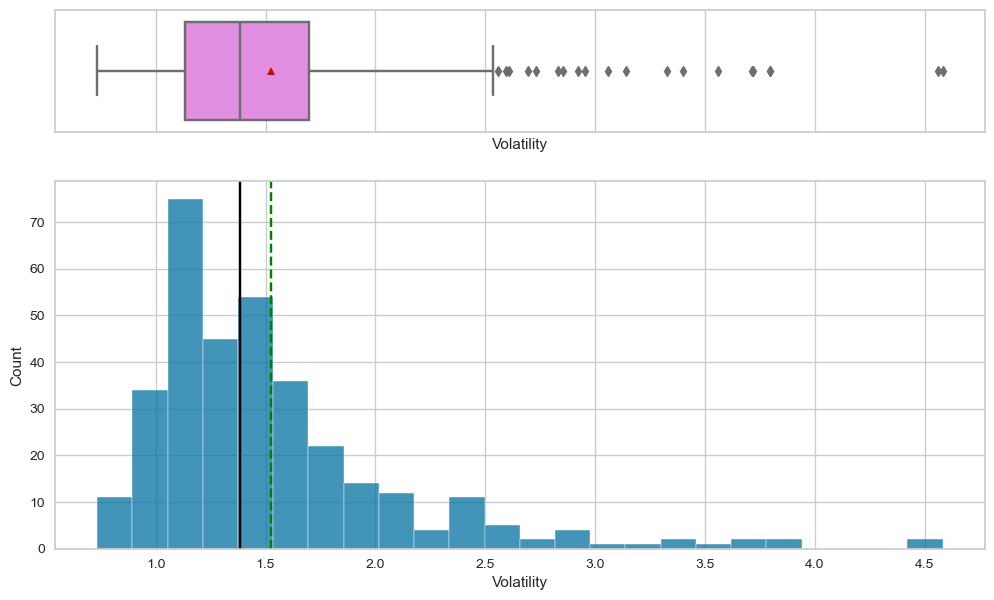

```python
histogram_boxplot(df, 'Volatility')
```

### Insights & Comments:

- The majority of the data points are clustered around the 1.0 to 2.0 volatility range. This suggests that a significant portion of the stocks in this dataset have relatively low to moderate volatility.
- The average volatility, indicated by the red triangle and the green dotted line, seems to be just above 1.5, suggesting that on average, the stocks in this dataset have a volatility slightly above this value.
- There are some stocks with very high volatility (above 3.0 and up to 4.5), as indicated by the outliers in the boxplot and the bars on the far right of the histogram. These might represent stocks that are particularly risky or have experienced significant price fluctuations.
- The boxplot suggests a tight interquartile range, which means that 50% of the data (between Q1 and Q3) is closely packed. This further emphasizes that a significant portion of the stocks have volatility values within a narrow range.

**In summary, while many stocks have low to moderate volatility, there are a few with very high volatility, indicating significant price fluctuations**

**`ROE`**

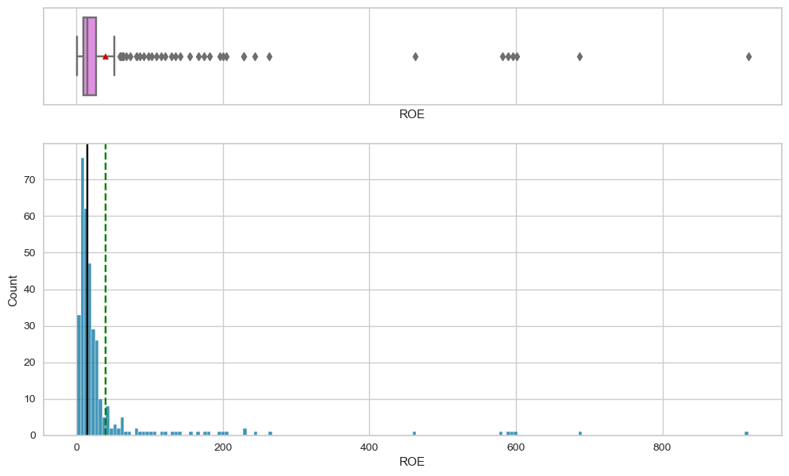

```python
histogram_boxplot(df, 'ROE')
```

### Insights & Comments:

**In summary, while many entities in this dataset have a low ROE, a few have exceptionally high ROE values, suggesting substantial returns relative to their equity.**

**`Cash Ratio`**

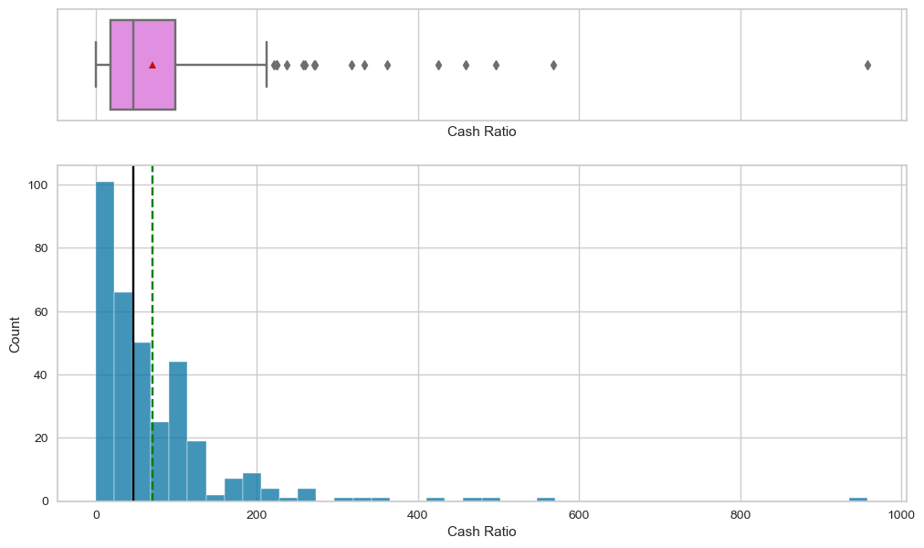

```python
histogram_boxplot(df, 'Cash Ratio')
```

### Insights & Comments:

- A significant proportion of the data is centered around 0 to 100, indicating that most entities (probably companies) in this dataset have a Cash Ratio in this range.
- The boxplot demonstrates that 50% of the data (from Q1 to Q3) is closely packed around the lower end, emphasizing the compact interquartile range.
- There are some outliers with significantly higher Cash Ratio values, which can be seen from the points on the right side of the boxplot and the less dense bars further right in the histogram.
- The average Cash Ratio, shown by the red triangle, is within the IQR, suggesting it is influenced by the bulk of companies with typical Cash Ratios, rather than by the outliers.

**To summarize, while many entities in this dataset have Cash Ratios clustered between 0 and 100, a few exhibit exceptionally high Cash Ratios.**

**`Net Cash Flow`**

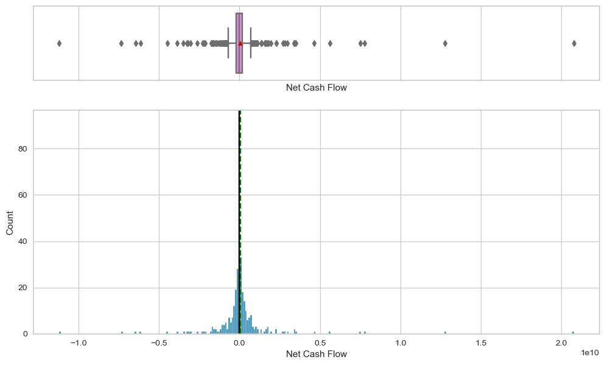

```python
histogram_boxplot(df, 'Net Cash Flow')
```

### Insights & Comments:

- A significant chunk of the data clusters around the zero mark, which suggests that for many entities in this dataset, their inflows and outflows of cash are relatively balanced.
- The boxplot’s tight IQR indicates that 50% of the data is closely packed around zero.
- The outliers, both on the positive and negative sides, suggest there are entities with substantial net inflows or outflows of cash. These might be indicative of big investments, divestitures, or other significant financial events.
- The presence of both negative and positive outliers can mean that while some entities experienced significant net cash inflows, others saw considerable net cash outflows.

**In summary, while many entities in the dataset have a Net Cash Flow near zero, indicating balanced cash transactions, there are a few entities with notably high positive or negative Net Cash Flows.**

**`Net Income`**

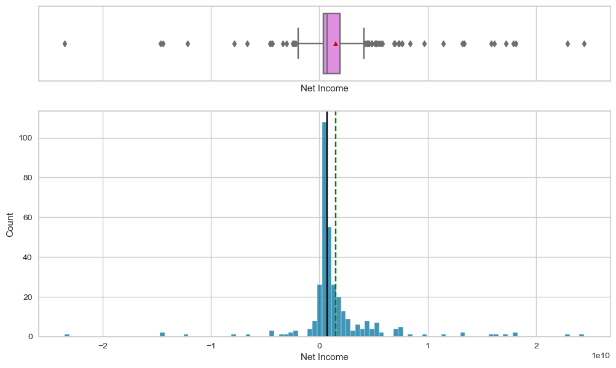

```python
histogram_boxplot(df, 'Net Income')
```

### Insights & Comments:

- A substantial portion of the data is clustered around the zero mark, indicating that many entities in this dataset either break even or have minimal net profit or loss.
- The boxplot’s IQR is relatively tight around zero, revealing that 50% of the entities have Net Income values close to zero.
- The outliers on both the positive and negative sides indicate some entities have either substantially high net profits or significant net losses. These outliers could stem from particular financial events, market conditions, or business strategies.

**In summary, this visualization for 'Net Income' provides insight into the general financial health and profitability of the entities in your dataset. While many entities seem to have a balanced financial outcome, some entities exhibit marked profitability or loss.**

**`Earnings Per Share`**

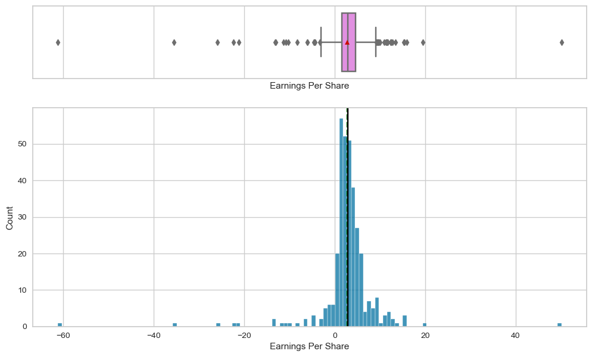

```python
histogram_boxplot(df, 'Earnings Per Share')
```

### Insights & Comments:

- A substantial portion of the data is clustered around the zero mark, indicating that many companies in this dataset either break even or have minimal net earnings relative to their number of outstanding shares.
- The boxplot’s IQR is relatively tight around zero, revealing that 50% of the companies have 'Earnings Per Share' values close to zero.
- The outliers on both the positive and negative sides indicate some companies have either substantially high earnings per share or significant losses per share. These outliers could stem from specific financial events, market conditions, mergers, acquisitions, or business strategies unique to these companies

**`Estimated Shares Outstanding`**

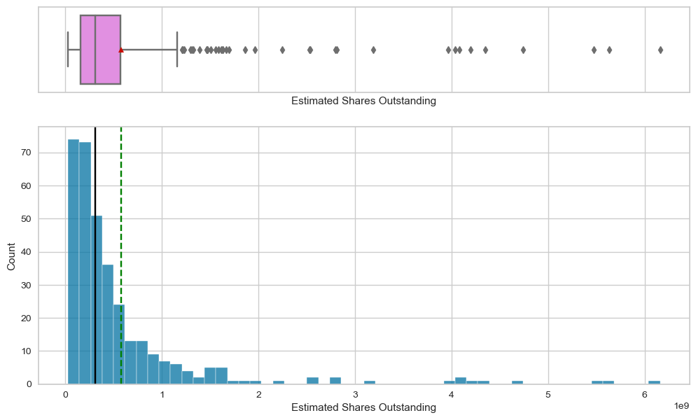

```python
histogram_boxplot(df, 'Estimated Shares Outstanding')
```

### Insights & Comments:

- The histogram reveals that many companies have fewer shares outstanding, with a significant number of them falling under 1e9 (1 billion) shares. The distribution is positively skewed.
- The boxplot’s IQR is positioned toward the lower end of the shares outstanding scale, indicating that 50% of the companies in this dataset have a relatively low number of shares outstanding.
- The presence of outliers on the right indicates that there are some companies with an exceptionally high number of shares outstanding. These could be large, established corporations or entities that have issued a significant number of shares for various strategic reasons.

**`P/E Ratio`**

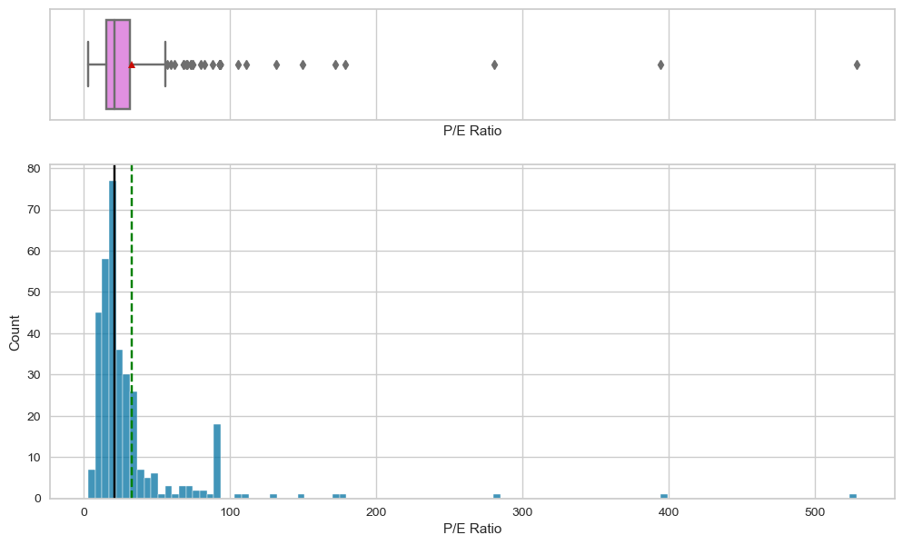

```python
histogram_boxplot(df, 'P/E Ratio')
```

Insights & Comments:

- The histogram suggests that many companies have P/E ratios in the lower range, with the majority falling under a P/E ratio of 100. The distribution is positively skewed.
- The boxplot’s IQR is positioned toward the lower end of the P/E ratio scale, suggesting that 50% of the companies have P/E ratios that are relatively low.
- The presence of outliers on the right signifies that there are companies with exceptionally high P/E ratios. This could indicate entities that are expected to have high future earnings or are priced at a premium due to perceived growth potential, brand value, or other intangible assets.
- A high P/E ratio could suggest that the market has high expectations for a company's future earnings growth, while a lower ratio might indicate the opposite or that the company is undervalued.

**`P/B Ratio`**

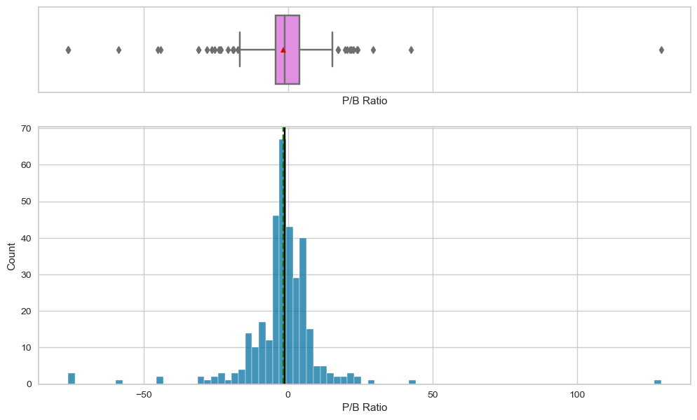

```python
histogram_boxplot(df, 'P/B Ratio')
```

### Insights & Comments:

- The histogram indicates that most companies have P/B ratios around 0, with a significant number just above and below this mark.
- The boxplot suggests that a majority of the companies have P/B ratios that are relatively close to one another, as denoted by the IQR's small range. This could suggest that the market value of these companies' stocks is relatively close to their book value.
- Negative P/B ratios are interesting and unusual. A negative ratio can occur when a company has negative shareholders' equity (i.e., liabilities exceed assets). This can be a red flag about the company's financial health.
- Outliers on both the left and right show that there are companies with exceptionally low and high P/B ratios, indicating entities that the market values either much below or much above their book values.

```python
# function to create labeled barplots


def labeled_barplot(df, feature, perc=False, n=None):
    """
    Barplot with percentage at the top

    data: dataframe
    feature: dataframe column
    perc: whether to display percentages instead of count (default is False)
    n: displays the top n category levels (default is None, i.e., display all levels)
    """

    total = len(df[feature])  # length of the column
    count = df[feature].nunique()
    if n is None:
        plt.figure(figsize=(count + 1, 5))
    else:
        plt.figure(figsize=(n + 1, 5))

    plt.xticks(rotation=90, fontsize=15)
    ax = sns.countplot(
        data=df,
        x=feature,
        palette="Paired",
        order=df[feature].value_counts().index[:n].sort_values(),
    )

    for p in ax.patches:
        if perc == True:
            label = "{:.1f}%".format(
                100 * p.get_height() / total
            )  # percentage of each class of the category
        else:
            label = p.get_height()  # count of each level of the category

        x = p.get_x() + p.get_width() / 2  # width of the plot
        y = p.get_height()  # height of the plot

        ax.annotate(
            label,
            (x, y),
            ha="center",
            va="center",
            size=12,
            xytext=(0, 5),
            textcoords="offset points",
        )  # annotate the percentage

    plt.show()  # show the plot
```

**`GICS Sector`**

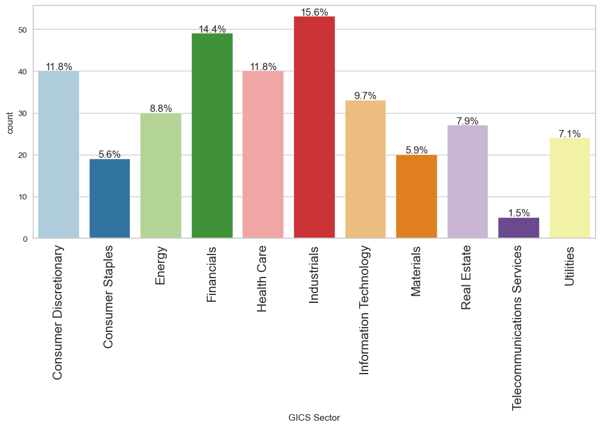

```python
labeled_barplot(df, 'GICS Sector', perc=True)
```

**`GICS Sub Industry`**

[figure not shown]

```python
labeled_barplot(df, 'GICS Sub Industry', perc=True)
```

### Bivariate Analysis

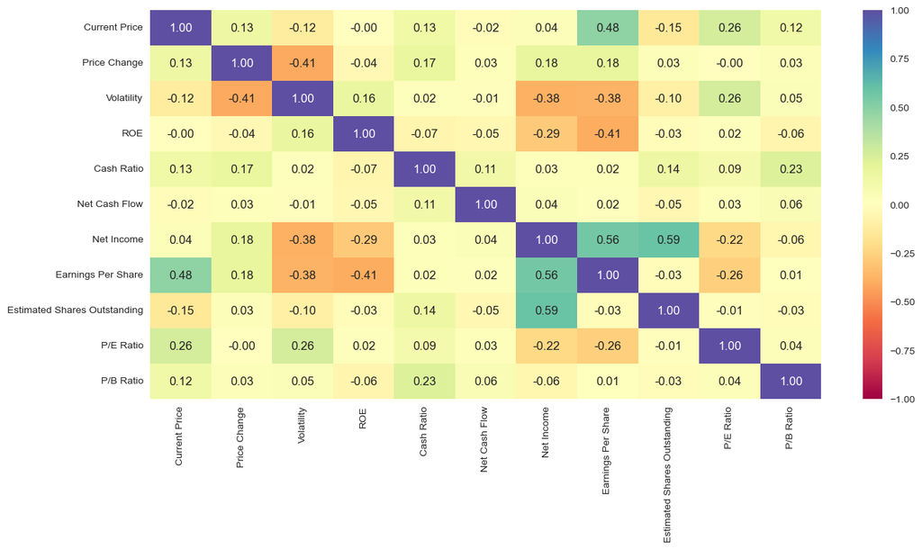

```python
# How are the different variables correlated with each other?
plt.figure(figsize=(15, 7))
sns.heatmap(
    df.corr(), annot=True, vmin=-1, vmax=1, fmt=".2f", cmap="Spectral"
)
plt.show()
```

## How are the different variables correlated with each other?

**Current Price:**

- Positively correlated with Earnings Per Share (0.48) and P/E Ratio (0.26).
- Mild positive correlation with Cash Ratio (0.13) and Price Change (0.13).
- Mild negative correlation with Volatility (-0.12).

**Price Change:**

- Strong negative correlation with Volatility (-0.41).
- Mild positive correlations with Net Income (0.18), Earnings Per Share (0.18), and Cash Ratio (0.17).

**Volatility:**

- Besides the strong negative correlation with Price Change (-0.41), it also has negative correlations with Earnings Per Share (-0.38) and Net Income (-0.38).
- Mild positive correlation with ROE (0.16).

**ROE (Return on Equity):**

- Positive correlation with Volatility (0.16).
- Negative correlations with Earnings Per Share (-0.41), Net Income (-0.29), and Cash Ratio (-0.07).

**Cash Ratio:**

- Positively correlated with Net Cash Flow (0.11).
- Negligible or very weak correlations with most other variables.

**Net Cash Flow:**

**Net Income:**

- Positively correlated with Earnings Per Share (0.56) and Estimated Shares Outstanding (0.59).
- Negative correlations with Volatility (-0.38) and ROE (-0.29).

**Earnings Per Share:**

- Strong positive correlation with Net Income (0.56).
- Negative correlations with Volatility (-0.38) and ROE (-0.41).

**Estimated Shares Outstanding:**

- Positive correlation with Net Income (0.59).
- Mild negative correlation with Current Price (-0.15).

**P/E Ratio:**

- Positively correlated with Current Price (0.26) and Volatility (0.26).
- Negative correlations with Earnings Per Share (-0.26) and Net Income (-0.22).

**P/B Ratio:**

- Mild positive correlations with Cash Ratio (0.23) and Current Price (0.12).
- Very weak or negligible correlations with most other variables.

## Data Preprocessing

- Duplicate value check
- Missing value treatment
- Outlier check
- Feature engineering (if needed)
- Any other preprocessing steps (if needed)

## The stocks of which economic sector have seen the maximum price increase on average?

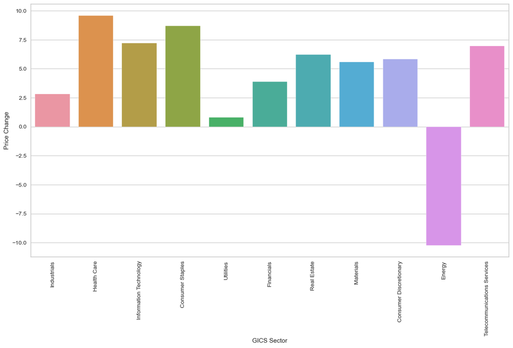

```python
plt.figure(figsize=(15,8))
sns.barplot(data=df, x='GICS Sector', y='Price Change', ci=False)
plt.xticks(rotation=90)
plt.show()
```

**Based on the barplot, the stocks of the "Health Care" economic sector have seen the maximum price increase on average.**

## Cash ratio provides a measure of a company's ability to cover its short-term obligations using only cash and cash equivalents. How does the average cash ratio vary across economic sectors?

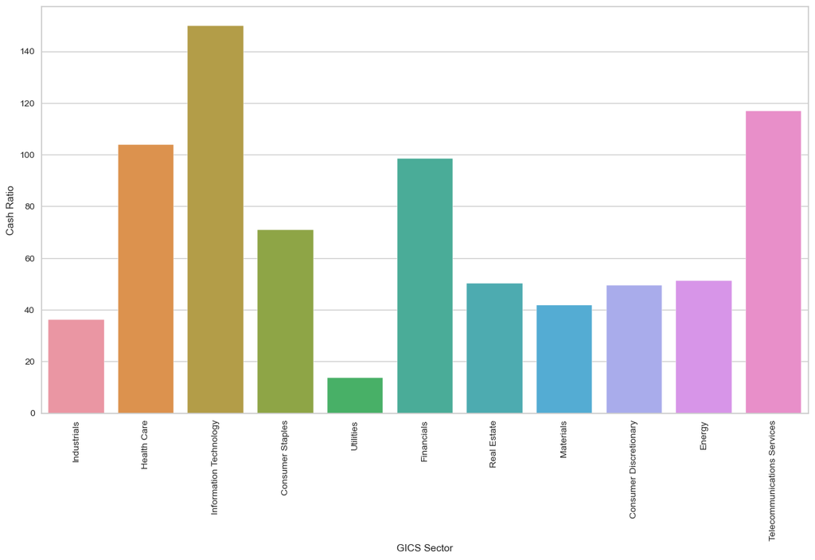

```python
plt.figure(figsize=(15,8))
sns.barplot(data=df, x='GICS Sector', y='Cash Ratio', ci=False)
plt.xticks(rotation=90)
plt.show()
```

## P/E ratios can help determine the relative value of a company's shares as they signify the amount of money an investor is willing to invest in a single share of a company per dollar of its earnings. How does the P/E ratio vary, on average, across economic sectors?

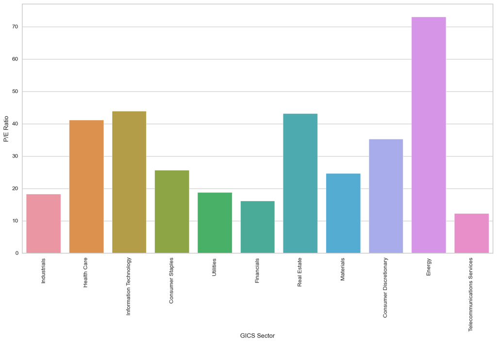

```python
plt.figure(figsize=(15,8))
sns.barplot(data=df, x='GICS Sector', y='P/E Ratio', ci=False)  ## Filled in the blanks
plt.xticks(rotation=90)
plt.show()
```

Observations:

**In summary:**

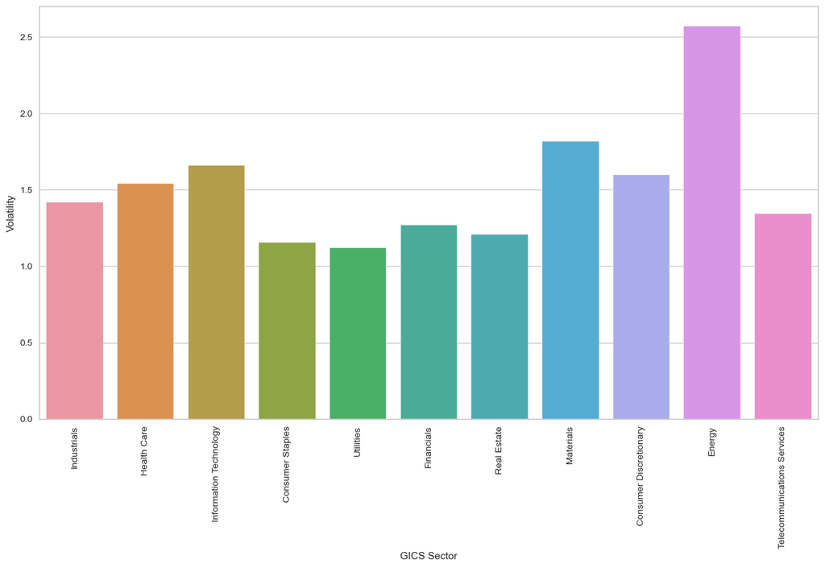

```python
plt.figure(figsize=(15,8))
sns.barplot(data=df, x='GICS Sector', y='Volatility', ci=False)
plt.xticks(rotation=90)
plt.show()
```

**Observations:**

## EDA

- It is a good idea to explore the data once again after manipulating it.

### Outlier Check

- Let's plot the boxplots of all numerical columns to check for outliers.

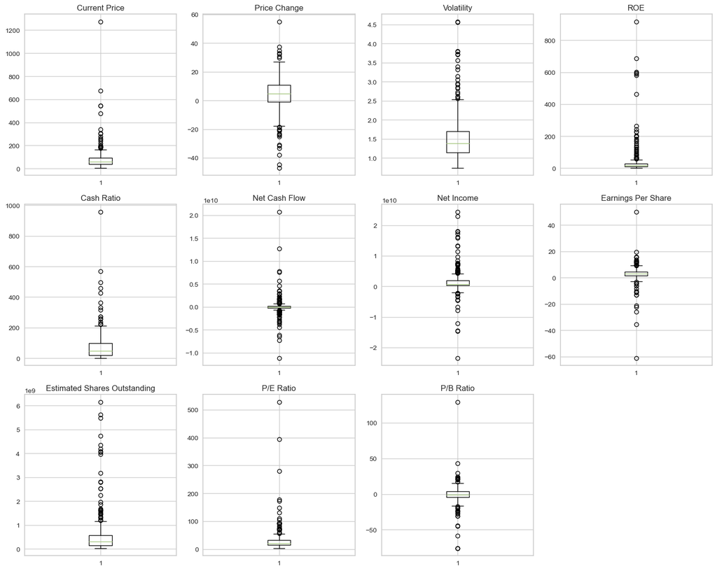

```python
plt.figure(figsize=(15, 12))

numeric_columns = df.select_dtypes(include=np.number).columns.tolist()

for i, variable in enumerate(numeric_columns):
    plt.subplot(3, 4, i + 1)
    plt.boxplot(df[variable], whis=1.5)
    plt.tight_layout()
    plt.title(variable)

plt.show()
```

### Observations:

**Current Price:**

- Median price is very low, close to 0.
- There are numerous high values that can be considered outliers, with some values reaching as high as around 1200.

**Price Change:**

- The median price change is around 0, indicating that half of the stocks did not experience significant change.
- There are outliers on both the positive and negative side, suggesting some stocks experienced significant price increases or decreases.

**Volatility:**

**ROE (Return On Equity):**

- The median ROE is very close to 0.
- A vast majority of the data is concentrated near 0, but there are some high outliers.

**Cash Ratio:**

- Median cash ratio is very low.
- Most of the data points are near 0, but there are several high outliers.

**Net Cash Flow:**

- The median is near 0.
- There's a concentration of data points around 0, with outliers on both the positive and negative side. This suggests that while many companies have a balanced cash flow, some have significant inflows or outflows.

**Net Income:**

- Median net income is near 0.
- Most companies seem to have their net income close to zero, but there are outliers in both positive and negative directions.

**Earnings Per Share:**

- The median earnings per share seems to be slightly positive.
- There are outliers in both the positive and negative direction, suggesting variability in earnings across companies.

**Estimated Shares Outstanding:**

- The median is relatively low.
- Most data is concentrated near the bottom, but there are several high outliers.

**P/E Ratio (Price-to-Earnings):**

- The median P/E ratio is slightly above 0.
- Most of the data is concentrated near the bottom, but there are some high outliers, suggesting some stocks might be considered overvalued.

**P/B Ratio (Price-to-Book):**

**Overall Summary**

**Several financial metrics, such as Current Price, Cash Ratio, and Estimated Shares Outstanding, have many outliers, suggesting variability in these metrics across different stocks. Metrics like Price Change, Net Cash Flow, Net Income, and Earnings Per Share have outliers on both ends, indicating that some companies are outperforming others, either positively or negatively. The presence of outliers in the P/E and P/B ratios suggests that some stocks might be overvalued or undervalued relative to others.**

### Scaling

- Let's scale the data before we proceed with clustering.

```python
# scaling the data before clustering
scaler = StandardScaler()
subset = df[numeric_columns]
subset_scaled = scaler.fit_transform(subset)
```

```python
# creating a dataframe of the scaled data
subset_scaled_df = pd.DataFrame(subset_scaled, columns=subset.columns)
```

## K-means Clustering

### Checking Elbow Plot

```python
k_means_df = subset_scaled_df.copy()
```

```
Number of Clusters: 1 	Average Distortion: 2.5425069919221697
Number of Clusters: 2 	Average Distortion: 2.382318498894466
Number of Clusters: 3 	Average Distortion: 2.2692367155390745
Number of Clusters: 4 	Average Distortion: 2.175554082632614
Number of Clusters: 5 	Average Distortion: 2.136852169310594
Number of Clusters: 6 	Average Distortion: 2.0713095032364506
Number of Clusters: 7 	Average Distortion: 1.9775989987671811
Number of Clusters: 8 	Average Distortion: 1.9652603012304684
Number of Clusters: 9 	Average Distortion: 1.9311613101229932
Number of Clusters: 10 	Average Distortion: 1.8502089919483546
Number of Clusters: 11 	Average Distortion: 1.824801480357901
Number of Clusters: 12 	Average Distortion: 1.7525839358924042
Number of Clusters: 13 	Average Distortion: 1.722563828836958
Number of Clusters: 14 	Average Distortion: 1.6973594266503265
```

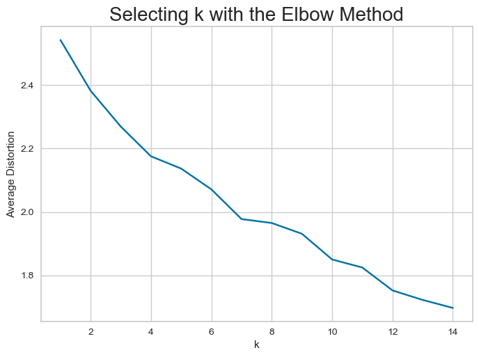

```python
clusters = range(1, 15)
meanDistortions = []

for k in clusters:
    model = KMeans(n_clusters=k, random_state=1)
    model.fit(subset_scaled_df)
    prediction = model.predict(k_means_df)
    distortion = (
        sum(np.min(cdist(k_means_df, model.cluster_centers_, "euclidean"), axis=1))
        / k_means_df.shape[0]
    )

    meanDistortions.append(distortion)

    print("Number of Clusters:", k, "\tAverage Distortion:", distortion)

plt.plot(clusters, meanDistortions, "bx-")
plt.xlabel("k")
plt.ylabel("Average Distortion")
plt.title("Selecting k with the Elbow Method", fontsize=20)
plt.show()
```

**Observations:**

- The most significant drops are observed between 1-6 clusters.
- The drop from 6 to 7 is also noticeable, but after that, the rate of decrease starts to slow down, especially between clusters 7 and 8 where it's only 0.0123.

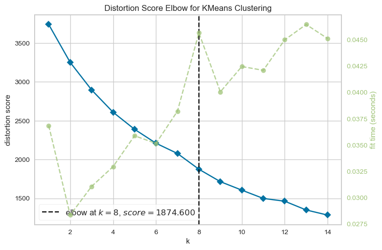

```python
model = KMeans(random_state=1)
visualizer = KElbowVisualizer(model, k=(1, 15), timings=True)
visualizer.fit(k_means_df)  # fit the data to the visualizer
visualizer.show()  # finalize and render figure
```

**Observation:**

### Let's check the silhouette scores

```
For n_clusters = 2, the silhouette score is 0.43969639509980457)
For n_clusters = 3, the silhouette score is 0.4644405674779404)
For n_clusters = 4, the silhouette score is 0.45434371948348606)
For n_clusters = 5, the silhouette score is 0.43169988466492354)
For n_clusters = 6, the silhouette score is 0.36698524210914063)
For n_clusters = 7, the silhouette score is 0.10587349598463779)
For n_clusters = 8, the silhouette score is 0.40021596082234684)
For n_clusters = 9, the silhouette score is 0.4051539505522535)
For n_clusters = 10, the silhouette score is 0.1147132918355368)
For n_clusters = 11, the silhouette score is 0.16268826704862685)
For n_clusters = 12, the silhouette score is 0.12883008320005324)
For n_clusters = 13, the silhouette score is 0.1744804713048242)
For n_clusters = 14, the silhouette score is 0.17597674098501367)
```

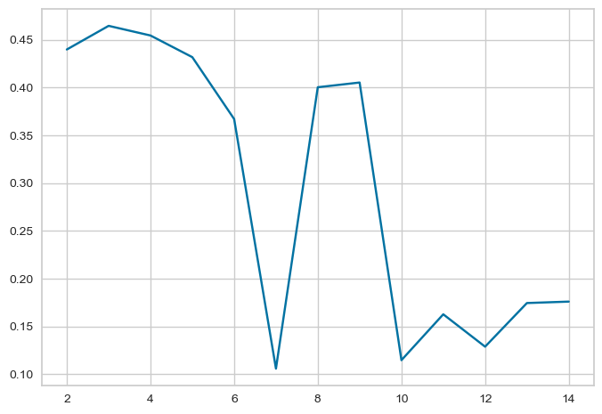

```python
sil_score = []
cluster_list = range(2, 15)
for n_clusters in cluster_list:
    clusterer = KMeans(n_clusters=n_clusters, random_state=1)
    preds = clusterer.fit_predict((subset_scaled_df))
    score = silhouette_score(k_means_df, preds)
    sil_score.append(score)
    print("For n_clusters = {}, the silhouette score is {})".format(n_clusters, score))

plt.plot(cluster_list, sil_score)
plt.show()
```

**Observations:**

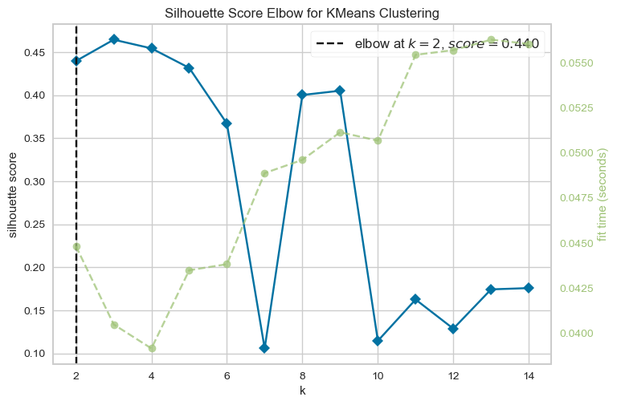

```python
model = KMeans(random_state=1)
visualizer = KElbowVisualizer(model, k=(2, 15), metric="silhouette", timings=True)
visualizer.fit(k_means_df)  # fit the data to the visualizer
visualizer.show()  # finalize and render figure
```

Observations:

- k=3 provides the highest silhouette score, suggesting the best cohesion and separation. Therefore, this might be considered as the optimal number of clusters based on the silhouette score.
- k=2 is highlighted as the "elbow" in the visualization. While it does not have the highest silhouette score, it has a reasonably high score with the advantage of simplicity by having fewer clusters.

**In summary, if the primary objective is to achieve the best clustering quality (based on silhouette score), k=3 would be the choice. However, if a simpler clustering configuration with fewer clusters is desired, then k=2 would be a good option.**

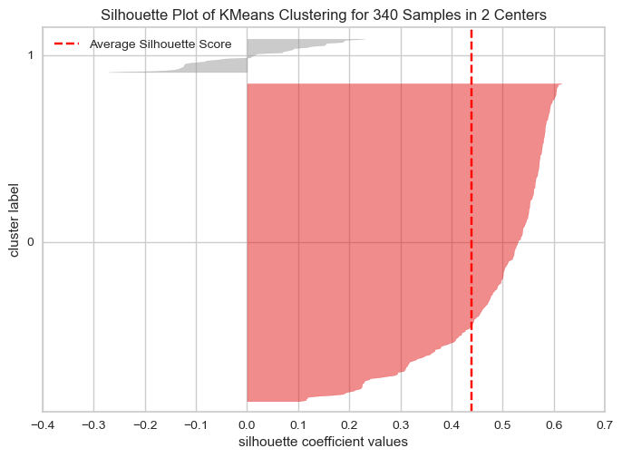

```python
# finding optimal no. of clusters with silhouette coefficients
visualizer = SilhouetteVisualizer(KMeans(n_clusters=2, random_state=1))
visualizer.fit(k_means_df)
visualizer.show()
```

**Observations:**

**Comparison with 3 Clusters:**

**Conclusion:**

### Creating Final Model

```python
kmeans = (KMeans(n_clusters=2, random_state=1))
kmeans.fit(k_means_df)
```

```
KMeans(n_clusters=2, random_state=1)
```

```python
# creating a copy of the original data
df1 = df.copy()

# adding kmeans cluster labels to the original and scaled dataframes
k_means_df["KM_segments"] = kmeans.labels_
df1["KM_segments"] = kmeans.labels_
```

### Cluster Profiling

```python
km_cluster_profile = df1.groupby("KM_segments").mean()  ## Grouping by the cluster labels "KM_segments"
```

```python
km_cluster_profile["count_in_each_segment"] = (
    df1.groupby("KM_segments")["Security"].count().values  ## Grouping by the cluster labels "KM_segments"
)
```

```python
km_cluster_profile.style.highlight_max(color="lightgreen", axis=0)
```

| KM_segments | Current Price | Price Change | Volatility | ROE | Cash Ratio | Net Cash Flow | Net Income | Earnings Per Share | Estimated Shares Outstanding | P/E Ratio | P/B Ratio | count_in_each_segment |
| --- | --- | --- | --- | --- | --- | --- | --- | --- | --- | --- | --- | --- |
| 0 | 82.786278 | 5.649217 | 1.391766 | 33.781759 | 70.159609 | 44922850.162866 | 1993143179.153095 | 3.896270 | 581977441.138534 | 24.244484 | -2.080438 | 307 |
| 1 | 62.963940 | -10.537087 | 2.774534 | 93.696970 | 68.757576 | 154287151.515152 | -3145581545.454545 | -7.639091 | 530986678.995152 | 110.461063 | 1.651207 | 33 |

### Observations:

- Cluster 0 represents companies that are currently profitable with positive earnings and net income. They also have a positive cash flow and relatively stable stock prices. There are more companies in this cluster, suggesting it represents the more "typical" or "average" companies in the dataset.
- Cluster 1 has companies with negative net income, indicating they are currently not profitable. However, they have a high ROE and a very high P/E ratio. The high P/E ratio might suggest that investors expect these companies to grow significantly in the future or that there are other factors driving the stock price. This cluster contains fewer companies, suggesting it represents the more "atypical" companies or perhaps those undergoing particular challenges or growth phases.

**In conclusion, the clusters provide a clear differentiation in terms of profitability, stock price behavior, and investor expectations. Investors might consider these clusters when making investment decisions based on their risk appetite and return expectations.**

```python
## code to print the companies in each cluster
for cl in df1["KM_segments"].unique():
    print("In cluster {}, the following companies are present:".format(cl))
    print(df1[df1["KM_segments"] == cl]["Security"].unique())
    print()
```

```
In cluster 0, the following companies are present:
['American Airlines Group' 'AbbVie' 'Abbott Laboratories'
 'Adobe Systems Inc' 'Archer-Daniels-Midland Co' 'Alliance Data Systems'
 'Ameren Corp' 'American Electric Power' 'AFLAC Inc'
 'American International Group, Inc.' 'Apartment Investment & Mgmt'
 'Assurant Inc' 'Arthur J. Gallagher & Co.' 'Akamai Technologies Inc'
 'Albemarle Corp' 'Alaska Air Group Inc' 'Allstate Corp' 'Allegion'
 'Applied Materials Inc' 'AMETEK Inc' 'Affiliated Managers Group Inc'
 'Amgen Inc' 'Ameriprise Financial' 'American Tower Corp A'
 'AutoNation Inc' 'Anthem Inc.' 'Aon plc' 'Amphenol Corp' 'Arconic Inc'
 'Activision Blizzard' 'AvalonBay Communities, Inc.' 'Broadcom'
 'American Water Works Company Inc' 'American Express Co' 'Boeing Company'
 'Bank of America Corp' 'Baxter International Inc.' 'BB&T Corporation'
 'Bard (C.R.) Inc.' 'BIOGEN IDEC Inc.' 'The Bank of New York Mellon Corp.'
 'Ball Corp' 'Bristol-Myers Squibb' 'Boston Scientific' 'BorgWarner'
 'Boston Properties' 'Citigroup Inc.' 'Caterpillar Inc.' 'Chubb Limited'
 'CBRE Group' 'Crown Castle International Corp.' 'Carnival Corp.'
 'Celgene Corp.' 'CF Industries Holdings Inc' 'Citizens Financial Group'
 'Church & Dwight' 'C. H. Robinson Worldwide' 'Charter Communications'
 'CIGNA Corp.' 'Cincinnati Financial' 'Colgate-Palmolive' 'Comerica Inc.'
 'CME Group Inc.' 'Chipotle Mexican Grill' 'Cummins Inc.' 'CMS Energy'
 'Centene Corporation' 'CenterPoint Energy' 'Capital One Financial'
 'The Cooper Companies' 'CSX Corp.' 'CenturyLink Inc'
 'Cognizant Technology Solutions' 'Citrix Systems' 'CVS Health'
 'Chevron Corp.' 'Dominion Resources' 'Delta Air Lines' 'Du Pont (E.I.)'
 'Deere & Co.' 'Discover Financial Services' 'Quest Diagnostics'
 'Danaher Corp.' 'The Walt Disney Company' 'Discovery Communications-A'
 'Discovery Communications-C' 'Delphi Automotive' 'Digital Realty Trust'
 'Dun & Bradstreet' 'Dover Corp.' 'Dr Pepper Snapple Group' 'Duke Energy'
 'DaVita Inc.' 'eBay Inc.' 'Ecolab Inc.' 'Consolidated Edison'
 'Equifax Inc.' "Edison Int'l" 'Eastman Chemical' 'Equinix'
 'Equity Residential' 'Eversource Energy' 'Essex Property Trust, Inc.'
 'E*Trade' 'Eaton Corporation' 'Entergy Corp.' 'Edwards Lifesciences'
 'Exelon Corp.' "Expeditors Int'l" 'Expedia Inc.' 'Extra Space Storage'
 'Ford Motor' 'Fastenal Co' 'Facebook' 'Fortune Brands Home & Security'
 'FirstEnergy Corp' 'Fidelity National Information Services' 'Fiserv Inc'
 'FLIR Systems' 'Fluor Corp.' 'Flowserve Corporation' 'FMC Corporation'
 'Federal Realty Investment Trust' 'First Solar Inc'
 'Frontier Communications' 'General Dynamics'
 'General Growth Properties Inc.' 'Gilead Sciences' 'Corning Inc.'
```

[output cut: 53 more lines]

```
 'Dentsply Sirona' 'Xerox Corp.' 'Xylem Inc.' 'Yahoo Inc.'
 'Yum! Brands Inc' 'Zimmer Biomet Holdings' 'Zions Bancorp' 'Zoetis']

In cluster 1, the following companies are present:
['Analog Devices, Inc.' 'Alexion Pharmaceuticals' 'Amazon.com Inc'
 'Apache Corporation' 'Anadarko Petroleum Corp' 'Baker Hughes Inc'
 'Chesapeake Energy' 'Cabot Oil & Gas' 'Concho Resources'
 'Devon Energy Corp.' 'EOG Resources' 'EQT Corporation'
 'Freeport-McMoran Cp & Gld' 'Halliburton Co.' 'Hess Corporation'
 'Hewlett Packard Enterprise' 'Kinder Morgan' 'Marathon Oil Corp.'
 'Murphy Oil' 'Noble Energy Inc' 'Netflix Inc.' 'Newfield Exploration Co'
 'National Oilwell Varco Inc.' 'ONEOK' 'Occidental Petroleum'
 'Quanta Services Inc.' 'Range Resources Corp.' 'Spectra Energy Corp.'
 'Southwestern Energy' 'Teradata Corp.' 'Williams Cos.' 'Wynn Resorts Ltd'
 'Cimarex Energy']
```

```python
df1.groupby(["KM_segments", "GICS Sector"])['Security'].count()
```

```
KM_segments  GICS Sector
0            Consumer Discretionary         38
             Consumer Staples               19
             Energy                          6
             Financials                     49
             Health Care                    39
             Industrials                    52
             Information Technology         29
             Materials                      19
             Real Estate                    27
             Telecommunications Services     5
             Utilities                      24
1            Consumer Discretionary          2
             Energy                         24
             Health Care                     1
             Industrials                     1
             Information Technology          4
             Materials                       1
Name: Security, dtype: int64
```

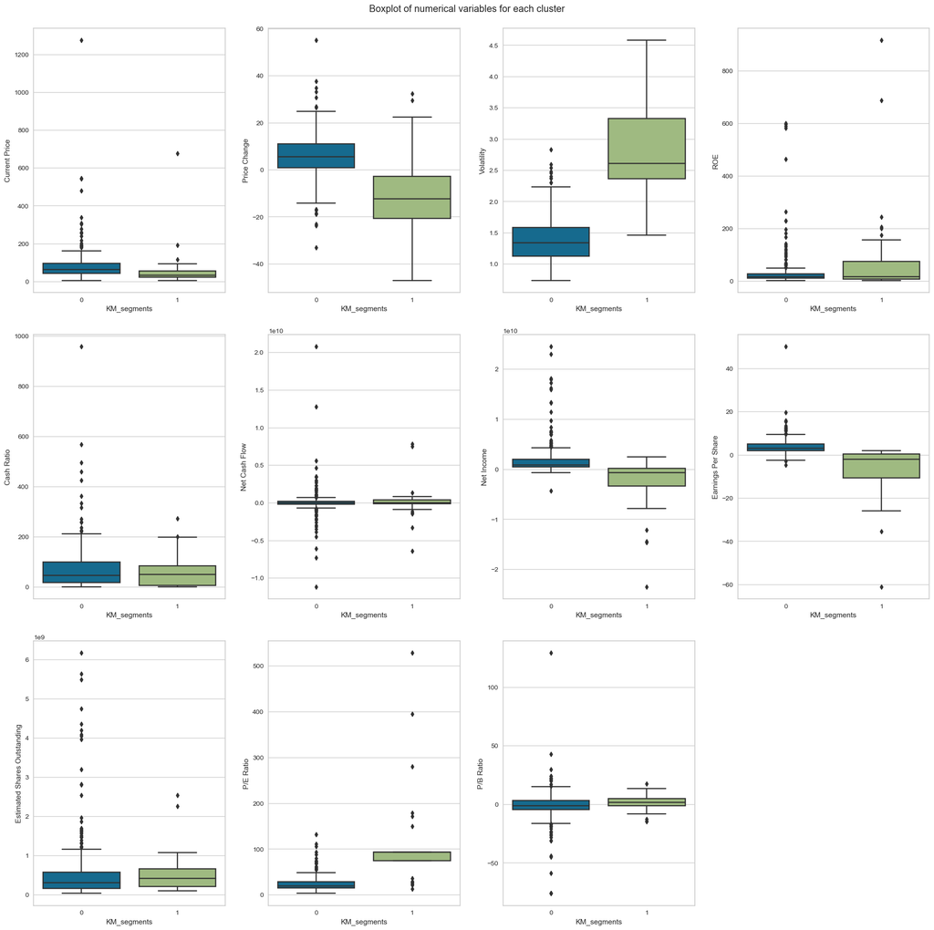

```python
plt.figure(figsize=(20, 20))
plt.suptitle("Boxplot of numerical variables for each cluster")

# selecting numerical columns
num_col = df.select_dtypes(include=np.number).columns.tolist()

for i, variable in enumerate(num_col):
    plt.subplot(3, 4, i + 1)
    sns.boxplot(data=df1, x="KM_segments", y=variable)

plt.tight_layout(pad=2.0)
```

### Overall Observations:

**Cluster 0:**

- This cluster represents a diversified group of companies spread across multiple sectors, with the Financials and Industrials sectors leading in representation. There's a broad market presence, with significant numbers from Consumer Discretionary, Health Care, Industrials, Financials, and Information Technology. The diverse nature of Cluster 0 suggests it encompasses firms that are relatively stable and might be following general market trends.

**Cluster 1:**

- Contrastingly, Cluster 1 is notably dominated by the Energy sector, indicating that this cluster captures specific dynamics or challenges related to this sector. The high representation of energy firms, combined with previously noted financial challenges in Cluster 1, suggests that this group may be undergoing specific industry pressures, potentially related to volatile oil prices or global shifts in energy consumption and production. The limited presence of other sectors further emphasizes the distinct character of this cluster, representing particular industry patterns more than broad market trends.

**In summary, while Cluster 0 offers a comprehensive view of the general market with a mix of industries, Cluster 1 provides insights into specific challenges and patterns predominant in the Energy sector.**

## Hierarchical Clustering

### Computing Cophenetic Correlation

```python
hc_df = subset_scaled_df.copy()
```

```python
# list of distance metrics
distance_metrics = ["euclidean", "chebyshev", "mahalanobis", "cityblock"]

# list of linkage methods
linkage_methods = ["single", "complete", "average", "weighted"]

high_cophenet_corr = 0
high_dm_lm = [0, 0]

for dm in distance_metrics:
    for lm in linkage_methods:
        Z = linkage(hc_df, metric=dm, method=lm)
        c, coph_dists = cophenet(Z, pdist(hc_df))
        print(
            "Cophenetic correlation for {} distance and {} linkage is {}.".format(
                dm.capitalize(), lm, c
            )
        )
        if high_cophenet_corr < c:
            high_cophenet_corr = c
            high_dm_lm[0] = dm
            high_dm_lm[1] = lm

# printing the combination of distance metric and linkage method with the highest cophenetic correlation
print('*'*100)
print(
    "Highest cophenetic correlation is {}, which is obtained with {} distance and {} linkage.".format(
        high_cophenet_corr, high_dm_lm[0].capitalize(), high_dm_lm[1]
    )
)
```

```
Cophenetic correlation for Euclidean distance and single linkage is 0.9232271494002922.
Cophenetic correlation for Euclidean distance and complete linkage is 0.7873280186580672.
Cophenetic correlation for Euclidean distance and average linkage is 0.9422540609560814.
Cophenetic correlation for Euclidean distance and weighted linkage is 0.8693784298129404.
Cophenetic correlation for Chebyshev distance and single linkage is 0.9062538164750717.
Cophenetic correlation for Chebyshev distance and complete linkage is 0.598891419111242.
Cophenetic correlation for Chebyshev distance and average linkage is 0.9338265528030499.
Cophenetic correlation for Chebyshev distance and weighted linkage is 0.9127355892367.
Cophenetic correlation for Mahalanobis distance and single linkage is 0.925919553052459.
Cophenetic correlation for Mahalanobis distance and complete linkage is 0.792530720285.
Cophenetic correlation for Mahalanobis distance and average linkage is 0.9247324030159737.
Cophenetic correlation for Mahalanobis distance and weighted linkage is 0.8708317490180426.
Cophenetic correlation for Cityblock distance and single linkage is 0.9334186366528574.
Cophenetic correlation for Cityblock distance and complete linkage is 0.7375328863205818.
Cophenetic correlation for Cityblock distance and average linkage is 0.9302145048594667.
Cophenetic correlation for Cityblock distance and weighted linkage is 0.731045513520281.
Highest cophenetic correlation is 0.9422540609560814, which is obtained with Euclidean distance and average linkage.
```

**Let's explore different linkage methods with Euclidean distance only.**

```python
# list of linkage methods
linkage_methods = ["single", "complete", "average", "centroid", "ward", "weighted"] ## code to add linkages

high_cophenet_corr = 0
high_dm_lm = [0, 0]

for lm in linkage_methods:
    Z = linkage(hc_df, metric="euclidean", method=lm)
    c, coph_dists = cophenet(Z, pdist(hc_df))
    print("Cophenetic correlation for {} linkage is {}.".format(lm, c))
    if high_cophenet_corr < c:
        high_cophenet_corr = c
        high_dm_lm[0] = "euclidean"
        high_dm_lm[1] = lm

# printing the combination of distance metric and linkage method with the highest cophenetic correlation
print('*'*100)
print(
    "Highest cophenetic correlation is {}, which is obtained with {} linkage.".format(
        high_cophenet_corr, high_dm_lm[1]
    )
)
```

```
Cophenetic correlation for single linkage is 0.9232271494002922.
Cophenetic correlation for complete linkage is 0.7873280186580672.
Cophenetic correlation for average linkage is 0.9422540609560814.
Cophenetic correlation for centroid linkage is 0.9314012446828154.
Cophenetic correlation for ward linkage is 0.7101180299865353.
Cophenetic correlation for weighted linkage is 0.8693784298129404.
Highest cophenetic correlation is 0.9422540609560814, which is obtained with average linkage.
```

**Let's view the dendrograms for the different linkage methods with Euclidean distance.**

### Checking Dendrograms

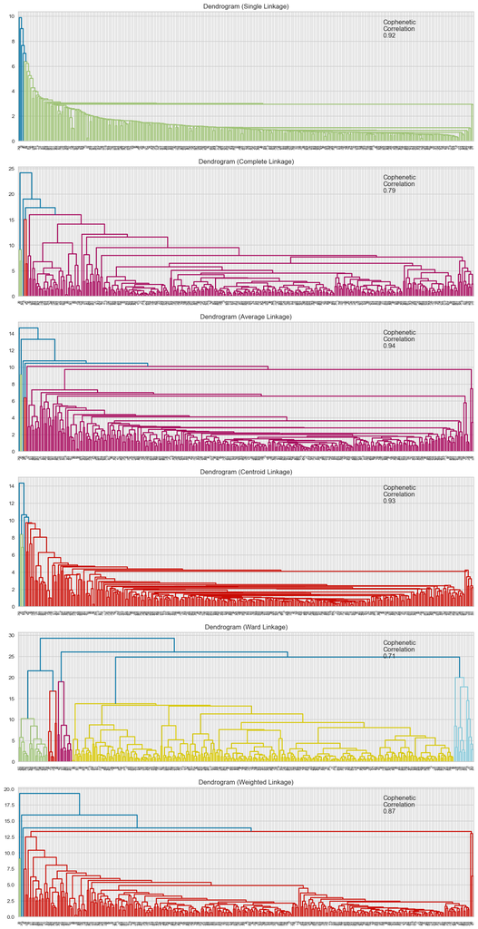

```python
# list of linkage methods
linkage_methods = ["single", "complete", "average", "centroid", "ward", "weighted"] ## code to add linkages

# lists to save results of cophenetic correlation calculation
compare_cols = ["Linkage", "Cophenetic Coefficient"]
compare = []

# to create a subplot image
fig, axs = plt.subplots(len(linkage_methods), 1, figsize=(15, 30))

# We will enumerate through the list of linkage methods above
# For each linkage method, we will plot the dendrogram and calculate the cophenetic correlation
for i, method in enumerate(linkage_methods):
    Z = linkage(hc_df, metric="euclidean", method=method)

    dendrogram(Z, ax=axs[i])
    axs[i].set_title(f"Dendrogram ({method.capitalize()} Linkage)")

    coph_corr, coph_dist = cophenet(Z, pdist(hc_df))
    axs[i].annotate(
        f"Cophenetic\nCorrelation\n{coph_corr:0.2f}",
        (0.80, 0.80),
        xycoords="axes fraction",
    )

    compare.append([method, coph_corr])
```

**Observation:**

- Average Linkage method appears to be the most suitable for this dataset, closely followed by the Centroid Linkage.

```python
# create and print a dataframe to compare cophenetic correlations for different linkage methods
df_cc = pd.DataFrame(compare, columns=compare_cols)
df_cc = df_cc.sort_values(by="Cophenetic Coefficient")
df_cc
```

|  | Linkage | Cophenetic Coefficient |
| --- | --- | --- |
| 4 | ward | 0.710118 |
| 1 | complete | 0.787328 |
| 5 | weighted | 0.869378 |
| 0 | single | 0.923227 |
| 3 | centroid | 0.931401 |
| 2 | average | 0.942254 |

### Creating model using sklearn

```python
HCmodel = AgglomerativeClustering(n_clusters=2, affinity="euclidean", linkage="average")
HCmodel.fit(subset_scaled_df)
```

```
AgglomerativeClustering(affinity='euclidean', linkage='average')
```

```python
# creating a copy of the original data
df2 = df.copy()

# adding hierarchical cluster labels to the original and scaled dataframes
hc_df["HC_segments"] = HCmodel.labels_
df2["HC_segments"] = HCmodel.labels_
```

### Cluster Profiling

```python
hc_cluster_profile = df2.groupby("HC_segments").mean()
```

```python
hc_cluster_profile["count_in_each_segment"] = (
    df2.groupby("HC_segments")["Security"].count().values  ## code to groupby the cluster labels
)
```

```python
hc_cluster_profile.style.highlight_max(color="lightgreen", axis=0)
```

| HC_segments | Current Price | Price Change | Volatility | ROE | Cash Ratio | Net Cash Flow | Net Income | Earnings Per Share | Estimated Shares Outstanding | P/E Ratio | P/B Ratio | count_in_each_segment |
| --- | --- | --- | --- | --- | --- | --- | --- | --- | --- | --- | --- | --- |
| 0 | 77.339962 | 4.080812 | 1.526736 | 39.628319 | 69.687316 | 60631790.560472 | 1491266681.415929 | 2.637094 | 578580233.983186 | 32.633682 | -1.720213 | 339 |
| 1 | 1274.949951 | 3.190527 | 1.268340 | 29.000000 | 184.000000 | -1671386000.000000 | 2551360000.000000 | 50.090000 | 50935516.070000 | 25.453183 | -1.052429 | 1 |

```python
## code to print the companies in each cluster
for cl in df2["HC_segments"].unique():
    print("In cluster {}, the following companies are present:".format(cl))
    print(df2[df2["HC_segments"] == cl]["Security"].unique())
    print()
```

```
In cluster 0, the following companies are present:
['American Airlines Group' 'AbbVie' 'Abbott Laboratories'
 'Adobe Systems Inc' 'Analog Devices, Inc.' 'Archer-Daniels-Midland Co'
 'Alliance Data Systems' 'Ameren Corp' 'American Electric Power'
 'AFLAC Inc' 'American International Group, Inc.'
 'Apartment Investment & Mgmt' 'Assurant Inc' 'Arthur J. Gallagher & Co.'
 'Akamai Technologies Inc' 'Albemarle Corp' 'Alaska Air Group Inc'
 'Allstate Corp' 'Allegion' 'Alexion Pharmaceuticals'
 'Applied Materials Inc' 'AMETEK Inc' 'Affiliated Managers Group Inc'
 'Amgen Inc' 'Ameriprise Financial' 'American Tower Corp A'
 'Amazon.com Inc' 'AutoNation Inc' 'Anthem Inc.' 'Aon plc'
 'Apache Corporation' 'Anadarko Petroleum Corp' 'Amphenol Corp'
 'Arconic Inc' 'Activision Blizzard' 'AvalonBay Communities, Inc.'
 'Broadcom' 'American Water Works Company Inc' 'American Express Co'
 'Boeing Company' 'Bank of America Corp' 'Baxter International Inc.'
 'BB&T Corporation' 'Bard (C.R.) Inc.' 'Baker Hughes Inc'
 'BIOGEN IDEC Inc.' 'The Bank of New York Mellon Corp.' 'Ball Corp'
 'Bristol-Myers Squibb' 'Boston Scientific' 'BorgWarner'
 'Boston Properties' 'Citigroup Inc.' 'Caterpillar Inc.' 'Chubb Limited'
 'CBRE Group' 'Crown Castle International Corp.' 'Carnival Corp.'
 'Celgene Corp.' 'CF Industries Holdings Inc' 'Citizens Financial Group'
 'Church & Dwight' 'Chesapeake Energy' 'C. H. Robinson Worldwide'
 'Charter Communications' 'CIGNA Corp.' 'Cincinnati Financial'
 'Colgate-Palmolive' 'Comerica Inc.' 'CME Group Inc.'
 'Chipotle Mexican Grill' 'Cummins Inc.' 'CMS Energy'
 'Centene Corporation' 'CenterPoint Energy' 'Capital One Financial'
 'Cabot Oil & Gas' 'The Cooper Companies' 'CSX Corp.' 'CenturyLink Inc'
 'Cognizant Technology Solutions' 'Citrix Systems' 'CVS Health'
 'Chevron Corp.' 'Concho Resources' 'Dominion Resources' 'Delta Air Lines'
 'Du Pont (E.I.)' 'Deere & Co.' 'Discover Financial Services'
 'Quest Diagnostics' 'Danaher Corp.' 'The Walt Disney Company'
 'Discovery Communications-A' 'Discovery Communications-C'
 'Delphi Automotive' 'Digital Realty Trust' 'Dun & Bradstreet'
 'Dover Corp.' 'Dr Pepper Snapple Group' 'Duke Energy' 'DaVita Inc.'
 'Devon Energy Corp.' 'eBay Inc.' 'Ecolab Inc.' 'Consolidated Edison'
 'Equifax Inc.' "Edison Int'l" 'Eastman Chemical' 'EOG Resources'
 'Equinix' 'Equity Residential' 'EQT Corporation' 'Eversource Energy'
 'Essex Property Trust, Inc.' 'E*Trade' 'Eaton Corporation'
 'Entergy Corp.' 'Edwards Lifesciences' 'Exelon Corp.' "Expeditors Int'l"
 'Expedia Inc.' 'Extra Space Storage' 'Ford Motor' 'Fastenal Co'
```

[output cut: 56 more lines]

```
 'United Continental Holdings' 'UDR Inc' 'Universal Health Services, Inc.'
 'United Health Group Inc.' 'Unum Group' 'Union Pacific'
 'United Parcel Service' 'United Technologies' 'Varian Medical Systems'
 'Valero Energy' 'Vulcan Materials' 'Vornado Realty Trust'
 'Verisk Analytics' 'Verisign Inc.' 'Vertex Pharmaceuticals Inc'
 'Ventas Inc' 'Verizon Communications' 'Waters Corporation'
 'Wec Energy Group Inc' 'Wells Fargo' 'Whirlpool Corp.'
 'Waste Management Inc.' 'Williams Cos.' 'Western Union Co'
 'Weyerhaeuser Corp.' 'Wyndham Worldwide' 'Wynn Resorts Ltd'
 'Cimarex Energy' 'Xcel Energy Inc' 'XL Capital' 'Exxon Mobil Corp.'
 'Dentsply Sirona' 'Xerox Corp.' 'Xylem Inc.' 'Yahoo Inc.'
 'Yum! Brands Inc' 'Zimmer Biomet Holdings' 'Zions Bancorp' 'Zoetis']

In cluster 1, the following companies are present:
['Priceline.com Inc']
```

```python
df2.groupby(["HC_segments", "GICS Sector"])['Security'].count()
```

```
HC_segments  GICS Sector
0            Consumer Discretionary         39
             Consumer Staples               19
             Energy                         30
             Financials                     49
             Health Care                    40
             Industrials                    53
             Information Technology         33
             Materials                      20
             Real Estate                    27
             Telecommunications Services     5
             Utilities                      24
1            Consumer Discretionary          1
Name: Security, dtype: int64
```

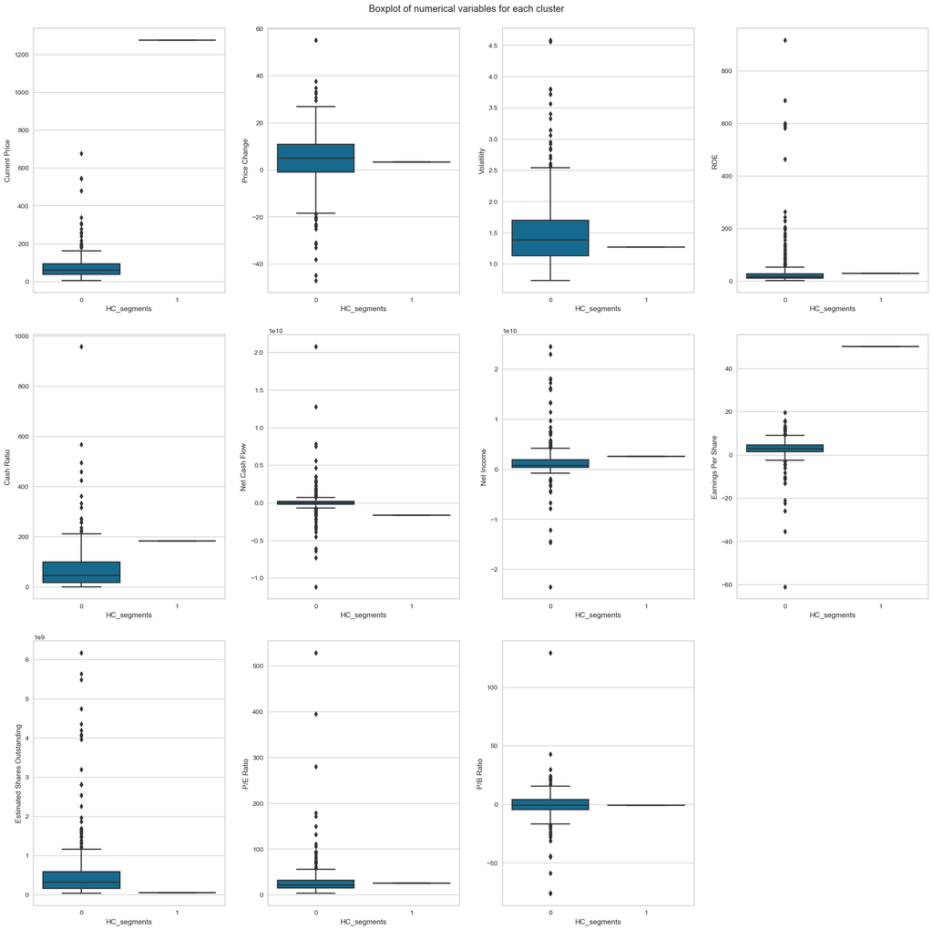

```python
plt.figure(figsize=(20, 20))
plt.suptitle("Boxplot of numerical variables for each cluster")

for i, variable in enumerate(num_col):
    plt.subplot(3, 4, i + 1)
    sns.boxplot(data=df2, x="HC_segments", y=variable)

plt.tight_layout(pad=2.0)
```

### Overall Insights:

**Cluster 0 represents a large group of stocks that have moderate current prices, a relatively high ROE, and a significant number of shares outstanding. The high cash ratio suggests strong liquidity positions, and the negative P/B ratio indicates that the market might undervalue these companies relative to their book values.**

**Cluster 1, on the other hand, consists of a single stock that has a very high current price, significant net income, and a high earnings per share. The stock also has a very high cash ratio, indicating a strong liquidity position, and a negative P/B ratio similar to Segment 0. The significant negative net cash flow suggests some caution.**

- Diversity: Cluster 0 is much more diverse in terms of both financial metrics and GICS sector representation. This cluster contains stocks from all sectors and a broad range of financial metrics.
- Unique Stock in Cluster 1: The stock in Cluster 1 stands out in terms of several financial metrics. It has a higher current price, earnings per share, and other metrics. It belongs to the Consumer Discretionary sector.
- Financial Characteristics: While Cluster 0 stocks are generally more moderate in their financial metrics, the stock in Cluster 1 tends to have superior metrics but also carries a significant negative net cash flow.

**In conclusion, the Hierarchical Clustering has grouped a large and diverse set of stocks into Cluster 0, while isolating a single, distinct stock in Cluster 1. When considering investment or further analysis, it's essential to dive deeper into the specifics of these clusters, especially the unique stock in Cluster 1, and to consider other external factors and industry trends.**

## K-means vs Hierarchical Clustering

**Execution Time:**

- While the exact time taken for both algorithms wasn't explicitly provided, typically, KMeans is faster, especially for large datasets. Hierarchical clustering tends to be more computationally intensive and could take longer for sizable datasets.

**Number of Clusters:**

- KMeans Clustering: The algorithm identified 2 clusters.
- Hierarchical Clustering: This too yielded 2 clusters.
- Both methods agreed upon the number of clusters, which provides some consistency in the analysis.

**Distinctiveness of Clusters:**

- KMeans Clustering: The clusters seemed to focus on different attributes. One cluster had stocks with higher prices, stable earnings, and positive net incomes. The other cluster had stocks with lower prices, higher volatility, and negative net incomes.
- Hierarchical Clustering: While it also yielded two clusters, the distinction seemed primarily based on stock price values and a few financial metrics. One cluster had significantly high stock prices, and the other contained the majority of stocks with more varied financial indicators.

**Number of Observations in Similar Clusters:**

**Cluster Profiles:**

- KMeans Clustering: Gave a clear distinction between stocks with high value, stability, and positive net incomes versus those with significant price drops, high volatility, and negative net incomes.
- Hierarchical Clustering: Offered a broader view, with one cluster heavily focused on high stock prices and another capturing a diverse range of financial attributes.
- In terms of granularity and specificity, KMeans provided a more nuanced differentiation, especially when considering financial health.

**Use Case Relevance:**

- KMeans Clustering: Given its efficiency and distinct clustering for this project, it may be more suitable for real-time or frequent stock data clustering for Trade&Ahead.
- Hierarchical Clustering: Provides a hierarchical structure that can be insightful for understanding nested relationships, but might be overkill for this specific project unless we're interested in multiple levels of stock categorization.

**Conclusion: Both KMeans and Hierarchical clustering provided valuable insights into the stock data. While they had some similarities in the clusters formed, the distinction and focus differed slightly. For Trade&Ahead's objectives, KMeans might be a more straightforward choice given its efficiency and the clarity of clusters it produced. However, Hierarchical clustering could be a complementary tool if there's interest in exploring nested relationships between stocks. It's essential to choose the clustering method based on the specific goals and computational resources at hand.**

## Actionable Insights and Recommendations

**High-Value Stocks vs. Volatile Stocks:**

**Financial Health Indicators:**

- A distinct group of companies (from the K-means clustering) showed negative net income and a significant drop in price change. Such stocks could indicate companies facing financial challenges. This might not be the safest bet for conservative investors but could be potential buy opportunities for investors looking for undervalued stocks that might rebound.

**Sector-Based Insights:**

**Stocks with High Returns on Equity (ROE):**

- There is a set of stocks with an exceptionally high ROE, especially in the K-means clustering. While a higher ROE can be a sign of a company's financial health, an excessively high ROE might need further investigation, as it might also be a sign of high financial leverage.

### Recommendations for Trade&Ahead:

**Diversification Strategy:**

- Given the sectoral differences in clusters, recommend clients diversify their portfolios across different sectors. This not only spreads the risk but also takes advantage of sector-specific growth opportunities.

**Risk Assessment:**

- Before suggesting any stock from the cluster with negative net income and drastic price changes, a deeper risk assessment should be performed. For clients with a higher risk appetite, they might be good options, but conservative clients should be made aware of potential pitfalls.

**Regular Monitoring:**

- Stocks that show high volatility and drastic price changes should be monitored more closely. Regularly tracking financial indicators for these stocks can help in timely decision-making.

**Further Investigation:**

- For stocks with outlier values (e.g., exceptionally high ROE), it might be worthwhile to do a deeper dive, checking other financial ratios and recent news about the company to get a comprehensive view.

**Customized Advisory:**

- Based on the financial goals and risk appetite of clients, recommend stocks from the respective clusters. For instance, conservative investors might prefer stocks from the High-Value cluster, while aggressive investors might be open to exploring the volatile stock cluster.

**Educate the Client:**

- It's essential to educate the clients about the characteristics of each cluster, helping them make informed decisions.

**Further Data Analysis:**

- While clustering provides a bird's-eye view of the stocks, it would be beneficial to conduct further time-series analysis on stock prices, dividend yields, and other financial indicators to refine investment strategies.

**Conclusion: Both KMeans and Hierarchical clustering provided valuable insights into the stock data. While they had some similarities in the clusters formed, the distinction and focus differed slightly. For Trade&Ahead's objectives, KMeans might be a more straightforward choice given its efficiency and the clarity of clusters it produced. However, Hierarchical clustering could be a complementary tool if there's interest in exploring nested relationships between stocks. It's essential to choose the clustering method based on the specific goals and computational resources at hand.**